# Pupil Yes/No Pilot Data Processed using GazeR

## Install Gazer

I had some trouble getting this to go and had to mannually install some of the needed packages (ggforce).

library(devtools) install_github(“dmirman/gazer”) library(ggforce)

## Read in data

Pupil data exported as individual reports for each participant and aggregated using merge_pupil function.

```r
library(tidyverse)
library(gazer)
library(dplyr)

file_list <-list.files(".", pattern = ".xls")
pupil_files <- merge_pupil(
  file_list,
  blink_colname = "AVERAGE_IN_BLINK",
  pupil_colname = "AVERAGE_PUPIL_SIZE"
)
```

## ‘Missingness’

Remove participants AND trials that have greater than a specified threshold of missing values (here 20%)

```r
pup_missing <- count_missing_pupil(pupil_files, missingthresh = .2)
```

```
## % trials excluded:0.462
```

```
## Participants taken out:PS05D
```

## De-blink

remove blinks AND 100ms window on each side of blink

```r
pup_extend<- pup_missing %>%
  group_by(subject, trial) %>%
  mutate(extendpupil=extend_blinks(pupil, fillback=100, fillforward=100, hz=1000))
```

## Removing other bad data

Plot a histogram and visually examine to determine what values are unlikely to be real measurements (based on recommendation by Mathot?). Alternatively we could set a threshold independently.

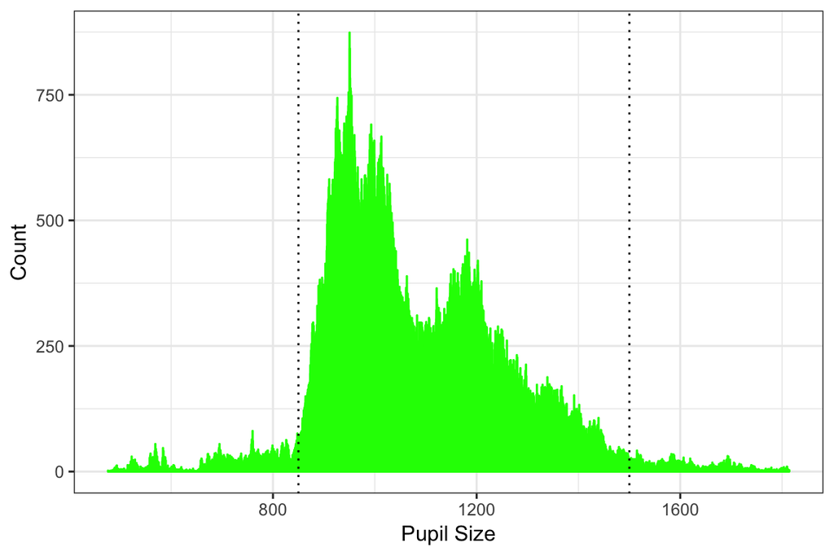

```r
puphist <- ggplot(pup_extend, aes(x = extendpupil)) +
  geom_histogram(aes(y = ..count..), colour = "green", binwidth = 0.5)  +
  geom_vline(xintercept = 850, linetype="dotted") +
  geom_vline(xintercept = 1500, linetype="dotted") +
  xlab("Pupil Size") +
  ylab("Count") +
  theme_bw()

print(puphist)
```

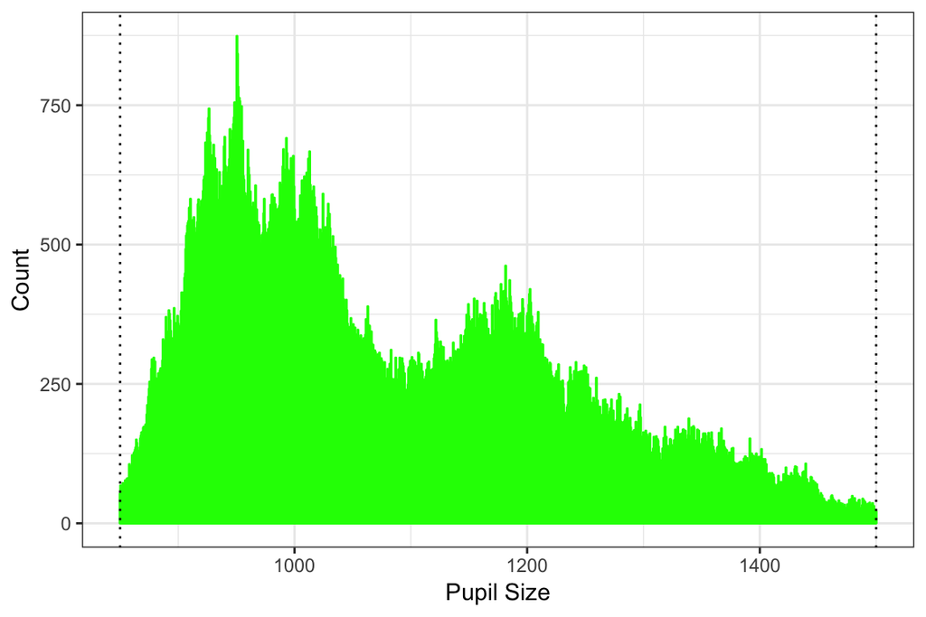

```r
pup_outliers <- pup_extend %>%
  filter(extendpupil >= 850, extendpupil <= 1500)

puphist_noOutliers <- ggplot(pup_outliers, aes(x = extendpupil)) +
  geom_histogram(aes(y = ..count..), colour = "green", binwidth = 0.5)  +
  geom_vline(xintercept = 850, linetype="dotted") +
  geom_vline(xintercept = 1500, linetype="dotted") +
  xlab("Pupil Size") +
  ylab("Count") +
  theme_bw()

print(puphist_noOutliers)
```

## Interpolate

Performs a linear interpolation of missing values

```r
pup_interp <- interpolate_pupil(
  pup_outliers,
  extendblinks = TRUE,
  type = "linear")
```

## MAD (speed of dialation)

May need to perform interpolation again after this step. MAD can not be performed with NAs in the dataset; at this time it must occur after interpolation.

```r
mad_removal <- pup_interp %>%
  group_by(subject, trial) %>%
  mutate(speed=speed_pupil(interp,time)) %>%
  mutate(MAD=calc_mad(speed)) %>%
  filter(speed < MAD)

#ggplot(data=mad_removal, aes(x=time, y=interp, colour = factor(subject))) + geom_point() + ylim(400, 1200) + facet_grid(cond ~ .)
```

## Interpolate

Performs a linear interpolation of missing values

```r
pup_interp2 <- interpolate_pupil(
  mad_removal,
  extendblinks = TRUE,
  type = "linear")
```

## Smoothing

Using moving average to smooth; window set to 8

```r
rolling_mean_pupil_average <- as.data.frame(pup_interp2) %>% #must be in a data.frame
  select(
    subject, trial, pupil,
    time, interp, sample_message, cond) %>%
  mutate(movingavgpup = moving_average_pupil(interp, n = 8))
```

## Baseline correction

```r
baseline_pupil <- baseline_correction_pupil(
  rolling_mean_pupil_average,
  pupil_colnames = "movingavgpup",
  baseline_window = c(event = c("Baseline_Onset"), event = c("Baseline_Offset")))

#ggplot(data=baseline_pupil, aes(x=time, y=baselinecorrectedp)) + geom_point() + ylim(-300, 300)
```

## Convert to meaningful units

### (we need to change this formula to fit our setup!!)

uses formula to change from abitrary unit to mm (we need to change this formula to fit our setup!!)

```r
timebinsmm <- baseline_pupil  %>%
  mutate(pupilmm = (sqrt(movingavgpup) * (0.119789246)))

#ggplot(data=timebinsmm, aes(x=time, y=pupilmm)) + geom_point() +
```

## Change trial onset to Zero

```r
baseline_pupil_onset <- timebinsmm %>%
  group_by(subject, trial) %>%
  mutate(time_zero= onset_pupil(time, sample_message, event = c("Stimulus_Onset") )) %>%
  ungroup() %>%
  filter(time_zero >= 0, time_zero <= 15000) %>%
  select(
    subject, trial, time, time_zero,
    sample_message, pupilmm, cond)

#ggplot(data=baseline_pupil_onset, aes(x=time_zero, y=pupilmm)) + geom_point()
```

## Binning and aggregating

Adds column assinging bins. Bin length set here to 250ms.

```r
timebins1 <- downsample_pupil(baseline_pupil_onset, bin.length=250)

head(timebins1)
```

```
## # A tibble: 6 x 8
##   subject trial  time time_zero sample_message pupilmm cond      timebins
##   <chr>   <int> <int>     <int> <chr>            <dbl> <chr>        <dbl>
## 1 PS04B       1  1296         0 Stimulus_Onset    4.51 WorldTrue        0
## 2 PS04B       1  1297         1 <NA>              4.51 WorldTrue        0
## 3 PS04B       1  1298         2 <NA>              4.51 WorldTrue        0
## 4 PS04B       1  1299         3 <NA>              4.51 WorldTrue        0
## 5 PS04B       1  1300         4 <NA>              4.51 WorldTrue        0
## 6 PS04B       1  1301         5 <NA>              4.51 WorldTrue        0
```

Group and summarize according to bin by condition

```r
agg_subject <- timebins1 %>%
  dplyr::group_by(subject, cond, timebins) %>%
  dplyr::summarise(aggbaseline=mean(pupilmm)) %>%
  ungroup()
```

## Plotting

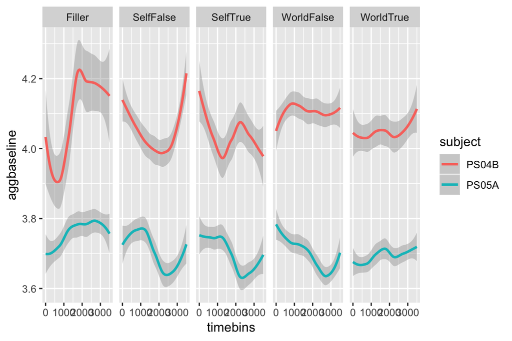

```r
plotByCond <- ggplot(agg_subject, aes(timebins, aggbaseline, color = subject)) +
  geom_smooth(method = loess) + facet_grid(.~ cond)

print(plotByCond)
```